# Water Column and Sediment Methanogens & Methanotrophs in FPV Ponds

## Fig S3: Betadisper

### Sediment Methanogens

```r
# 1. methanogens
# Homogeneity of Disperson test with beta dispr

## Bray-Curtis
betadispr_sed_methanogens_pond <-
  betadisper(sed_gen_bray, sed_methanogens_metadata$Pond)

betadispr_sed_methanogens_solar <-
  betadisper(sed_gen_bray, sed_methanogens_metadata$solar_progress)

betadispr_sed_methanogens_JDate <-
  betadisper(sed_gen_bray, sed_methanogens_metadata$JDate)

# permutest() performs a non-parametric permutation test, which is robust and valid for the kind of data used in beta diversity analysis (e.g., dissimilarity matrices).
permutest(betadispr_sed_methanogens_pond) # not significant p = 0.659
```

```
##
## Permutation test for homogeneity of multivariate dispersions
## Permutation: free
## Number of permutations: 999
##
## Response: Distances
##           Df   Sum Sq   Mean Sq      F N.Perm Pr(>F)
## Groups     5 0.028166 0.0056333 0.8054    999  0.556
## Residuals 38 0.265794 0.0069946
```

```r
permutest(betadispr_sed_methanogens_solar) # not significant p = 0.067
```

```
##
## Permutation test for homogeneity of multivariate dispersions
## Permutation: free
## Number of permutations: 999
##
## Response: Distances
##           Df   Sum Sq   Mean Sq      F N.Perm Pr(>F)
## Groups     1 0.009152 0.0091520 2.6864    999  0.112
## Residuals 42 0.143087 0.0034068
```

```r
permutest(betadispr_sed_methanogens_JDate) # not significant p = 0.44
```

```
##
## Permutation test for homogeneity of multivariate dispersions
## Permutation: free
## Number of permutations: 999
##
## Response: Distances
##           Df   Sum Sq   Mean Sq      F N.Perm Pr(>F)
## Groups     3 0.005044 0.0016812 0.6919    999  0.599
## Residuals 40 0.097192 0.0024298
```

### Sediment Methanotrophs

```r
# 2. methanotrophs
# Homogeneity of Disperson test with beta dispr

## Bray-Curtis
betadispr_sed_methanotrophs_pond <-
  betadisper(sed_troph_bray, sed_methanotrophs_metadata$Pond)

betadispr_sed_methanotrophs_solar <-
  betadisper(sed_troph_bray, sed_methanotrophs_metadata$solar_progress)

betadispr_sed_methanotrophs_JDate <-
  betadisper(sed_troph_bray, sed_methanotrophs_metadata$JDate)


# permutest() performs a non-parametric permutation test, which is robust and valid for the kind of data used in beta diversity analysis (e.g., dissimilarity matrices).
permutest(betadispr_sed_methanotrophs_pond) # not significant p = 0.515
```

```
##
## Permutation test for homogeneity of multivariate dispersions
## Permutation: free
## Number of permutations: 999
##
## Response: Distances
##           Df  Sum Sq   Mean Sq      F N.Perm Pr(>F)
## Groups     5 0.01643 0.0032859 0.3902    999   0.83
## Residuals 38 0.31997 0.0084203
```

```r
permutest(betadispr_sed_methanotrophs_solar) # not significant p = 0.682
```

```
##
## Permutation test for homogeneity of multivariate dispersions
## Permutation: free
## Number of permutations: 999
##
## Response: Distances
##           Df   Sum Sq   Mean Sq     F N.Perm Pr(>F)
## Groups     1 0.000131 0.0001305 0.023    999  0.873
## Residuals 42 0.238617 0.0056814
```

```r
permutest(betadispr_sed_methanotrophs_JDate) # significant p = 0.011 *
```

```
##
## Permutation test for homogeneity of multivariate dispersions
## Permutation: free
## Number of permutations: 999
##
## Response: Distances
##           Df   Sum Sq   Mean Sq     F N.Perm Pr(>F)
## Groups     3 0.023559 0.0078532 3.259    999  0.026 *
## Residuals 40 0.096386 0.0024097
## ---
## Signif. codes:  0 '***' 0.001 '**' 0.01 '*' 0.05 '.' 0.1 ' ' 1
```

**Sediment Methanogens** With betadispr we find the PERMANOVA results are are valid as pond, treatment, and date are not significant but significant in the PERMANOVA. Thus our PERMANOVA result is reliable and the differences between groups are due to location/centroids of groups rather than differences in variation within groups

**Sediment Methanotrophs** With betadispr we find the PERMANOVA results are are valid as pond and treatment are not significant but significant in the PERMANOVA. Thus our PERMANOVA result is reliable and the differences between groups are due to location/centroids of groups rather than differences in variation within groups

However, date is statistically significant in PERMANOVA and in the betadispr indicating that theres variability in within the sampling dates so there are likely differences in community composition and probably heterogeneity over time.

# Table S6 - Taxonomy Table

reformat later

```r
# water
taxonomy_table <- tax_table(water_ch4_cyclers_physeq) %>%
  as.data.frame() %>%
  tibble::rownames_to_column("OTU")

order_genus_summary <- taxonomy_table %>%
  group_by(Kingdom, Phylum, Class, Order, Family) %>%
  summarize(
    Genera = paste(sort(unique(Genus[!is.na(Genus)])), collapse = ", ")
  ) %>%
  arrange(Phylum, Class, Order, Family)
order_genus_summary
```

```
## # A tibble: 15 × 6
## # Groups:   Kingdom, Phylum, Class, Order [10]
##    Kingdom  Phylum                   Class               Order                    Family                   Genera
##    <chr>    <chr>                    <chr>               <chr>                    <chr>                    <chr>
##  1 Archaea  Halobacteriota           Methanocellia       Methanocellales          Methanocellaceae         "Methanocella_A"
##  2 Archaea  Halobacteriota           Methanomicrobia     Methanomicrobiales       Methanomicrobiaceae      ""
##  3 Archaea  Halobacteriota           Methanomicrobia     Methanomicrobiales       Methanospirillaceae_2121 "Methanolinea_A, Methanoregula, UBA467"
##  4 Archaea  Halobacteriota           Methanomicrobia     Methanomicrobiales       Methanospirillaceae_2125 "Methanospirillum"
##  5 Archaea  Halobacteriota           Methanosarcinia     Methanosarcinales_A_2632 Methanosarcinaceae       "Methanosarcina_2619"
##  6 Archaea  Halobacteriota           Methanosarcinia     Methanotrichales         Methanotrichaceae        "Methanothrix_B"
##  7 Archaea  Methanobacteriota_A_1229 Methanobacteria     Methanobacteriales       Methanobacteriaceae      "Methanobacterium_A, Methanobacterium_B_963, Methanobacterium_D_1054, Methanobacterium_F_900, Methanobrevibacter_D, Methanosphaera"
##  8 Archaea  Methanobacteriota_B      Thermococci         Methanofastidiosales     Methanofastidiosaceae    "Methanofastidiosum"
##  9 Bacteria Methylomirabilota        Methylomirabilia    Methylomirabilales       2-02-FULL-66-22          "2-02-FULL-66-22"
## 10 Bacteria Pseudomonadota           Alphaproteobacteria Rhizobiales_505101       Beijerinckiaceae         "Methylocystis"
## 11 Bacteria Pseudomonadota           Gammaproteobacteria Methylococcales          Methylococcaceae         "Methylococcus, Methylomagnum, Methyloparacoccus, Methyloterricola, Methylotetracoccus, UBA6136"
## 12 Bacteria Pseudomonadota           Gammaproteobacteria Methylococcales          Methylomonadaceae        "Crenothrix, Methylobacter_C_601048, Methylobacter_C_601751, Methyloglobulus, Methylomonas, Methylosoma, Methylovulum, UBA4132"
## 13 Archaea  Thermoplasmatota         Thermoplasmata_1773 Methanomassiliicoccales  Methanomassiliicoccaceae "Methanomassiliicoccus_A_1624"
## 14 Archaea  Thermoplasmatota         Thermoplasmata_1773 Methanomassiliicoccales  Methanomethylophilaceae  ""
## 15 Archaea  Thermoplasmatota         Thermoplasmata_1773 Methanomassiliicoccales  UBA472                   "FEN-33"
```

```r
# sediment

taxonomy_table_s <- tax_table(sed_ch4_cyclers_physeq) %>%
  as.data.frame() %>%
  tibble::rownames_to_column("OTU")

order_genus_summary_s <- taxonomy_table_s %>%
  group_by(Kingdom, Phylum, Class, Order, Family) %>%
  summarize(
    Genera = paste(sort(unique(Genus[!is.na(Genus)])), collapse = ", ")
  ) %>%
  arrange(Phylum, Class, Order, Family)
order_genus_summary_s
```

```
## # A tibble: 15 × 6
## # Groups:   Kingdom, Phylum, Class, Order [10]
##    Kingdom  Phylum                   Class               Order                    Family                   Genera
##    <chr>    <chr>                    <chr>               <chr>                    <chr>                    <chr>
##  1 Archaea  Halobacteriota           Methanocellia       Methanocellales          Methanocellaceae         "Methanocella_A"
##  2 Archaea  Halobacteriota           Methanomicrobia     Methanomicrobiales       Methanomicrobiaceae      ""
##  3 Archaea  Halobacteriota           Methanomicrobia     Methanomicrobiales       Methanospirillaceae_2121 "Methanolinea_A, Methanolinea_B, Methanoregula, UBA288, UBA467"
##  4 Archaea  Halobacteriota           Methanomicrobia     Methanomicrobiales       Methanospirillaceae_2125 "Methanospirillum"
##  5 Archaea  Halobacteriota           Methanosarcinia     Methanosarcinales_A_2632 Methanoperedenaceae      "Methanoperedens_A"
##  6 Archaea  Halobacteriota           Methanosarcinia     Methanosarcinales_A_2632 Methanosarcinaceae       "Methanomethylovorans, Methanosarcina_2619"
##  7 Archaea  Halobacteriota           Methanosarcinia     Methanotrichales         Methanotrichaceae        "Methanothrix_B"
##  8 Archaea  Methanobacteriota_A_1229 Methanobacteria     Methanobacteriales       Methanobacteriaceae      "Methanobacterium_A, Methanobacterium_B_963, Methanobacterium_C, Methanobacterium_D_1054, Methanobacterium_F_896, Methanobacterium_F_900, Meth…
##  9 Bacteria Methylomirabilota        Methylomirabilia    Methylomirabilales       2-02-FULL-66-22          "2-02-FULL-66-22"
## 10 Bacteria Pseudomonadota           Alphaproteobacteria Rhizobiales_505101       Beijerinckiaceae         "Methylocystis"
## 11 Bacteria Pseudomonadota           Gammaproteobacteria Methylococcales          Methylococcaceae         "Methylocaldum, Methylococcus, Methylomagnum, Methyloparacoccus, Methyloterricola, Methylotetracoccus"
## 12 Bacteria Pseudomonadota           Gammaproteobacteria Methylococcales          Methylomonadaceae        "Crenothrix, Methylobacter_C_601048, Methylobacter_C_601751, Methyloglobulus, Methylomonas, Methylosoma, UBA4132"
## 13 Archaea  Thermoplasmatota         Thermoplasmata_1773 Methanomassiliicoccales  Methanomassiliicoccaceae "Methanomassiliicoccus_A_1624"
## 14 Archaea  Thermoplasmatota         Thermoplasmata_1773 Methanomassiliicoccales  UBA472                   "FEN-33"
## 15 Archaea  Thermoproteota           Methanomethylicia   Methanomethylicales      Methanomethylicaceae     "Methanomethylicus"
```

# Plot DO vs Methanotroph Abundance Dynamics

1. Plot DO dynamics over 2024 sampling season.
2. Plot methanotroph abundances overtime.
- first we will plot all methanotrophs (gammaproteobacterial and alphaproteobacterial) abundances overtime
- filter for gammaproteobacterial and alphaproteobacterial methanotroph abundances
  - gammaproteobacterial (historically named type I methanotrophs) dominate the system but curious about alphaproteobacterial (historically type II) abundance and NC10 that are anaerobic methane oxidizers
    - note the designation type I and type II are just historical names at this point!
3. Then we will plot all water column methanotrophs against DO concentrations. Could separate this further by gamma and alphaproteobacterial methanotrophs but wont be doing that now.

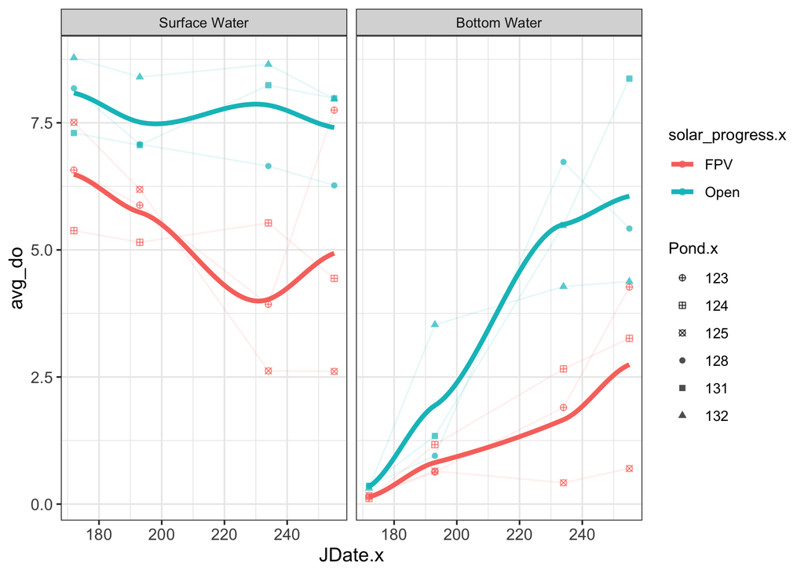

```r
# load metadata with DO concentrations, could also plot as DO % saturation
load("data/00_load_data/chem_metadata_23_24.RData")

# load in water_ch4_cycler_df data frame before we manipulated it when we calculated normality
load("data/01_phyloseq/water_ch4_cyclers_df.RData")

# set levels
water_ch4_cyclers_df$solar_progress <- factor(
  water_ch4_cyclers_df$solar_progress,
  levels = c("FPV", "Open"))

# factor depth
water_ch4_cyclers_df$Depth_Class <- factor(
  water_ch4_cyclers_df$Depth_Class,
  levels = c("Surface Water", "Bottom Water"))

# rename df to preserver abundance data whcih we will calculate below
water_ch4_cyclers_df_dynamics <- water_ch4_cyclers_df

# now add interaction column to our df for temporal dynamics old code im not ready to delete
# water_ch4_cyclers_df_dynamics <- water_ch4_cyclers_df %>%
#   mutate(group = interaction(CH4_Cycler, Depth_Class, sep = " ")) %>%
#   group_by(Pond, solar_progress, Depth_Class, group, JDate, CH4_Cycler, DNA_ID) %>%
#   summarise(
#     total_abundance = sum(Abundance, na.rm = TRUE), # total abundance across all samples
#     .groups = "drop"
#   )

# join with chem metadata with abundance data for temporal dynamics
do_abundance <- left_join(water_ch4_cyclers_df_dynamics, chem_metadata_23_24, by = "DNA_ID")

# 1. plot DO mg/L overtime; can alternatively plot with DO % saturation
do_mgl <- do_abundance %>%
  group_by(JDate.x, Pond.x, solar_progress.x, Depth_Class.x) %>%
  summarise(avg_do = mean(HDO_mg.l, na.rm = TRUE), .groups = "drop") %>%
  ggplot(aes(x = JDate.x,
             y = avg_do,
             color = solar_progress.x,
             fill = solar_progress.x,
             group = Pond.x,
             shape = Pond.x)) +
  geom_line(alpha = 0.1) +
  geom_smooth(aes(group = solar_progress.x), se = FALSE, linewidth = 1.4) +
  geom_point(alpha = 0.7) +
  scale_shape_manual(values = pond_shapes)+
  ggh4x::facet_wrap2(~Depth_Class.x)
do_mgl
```

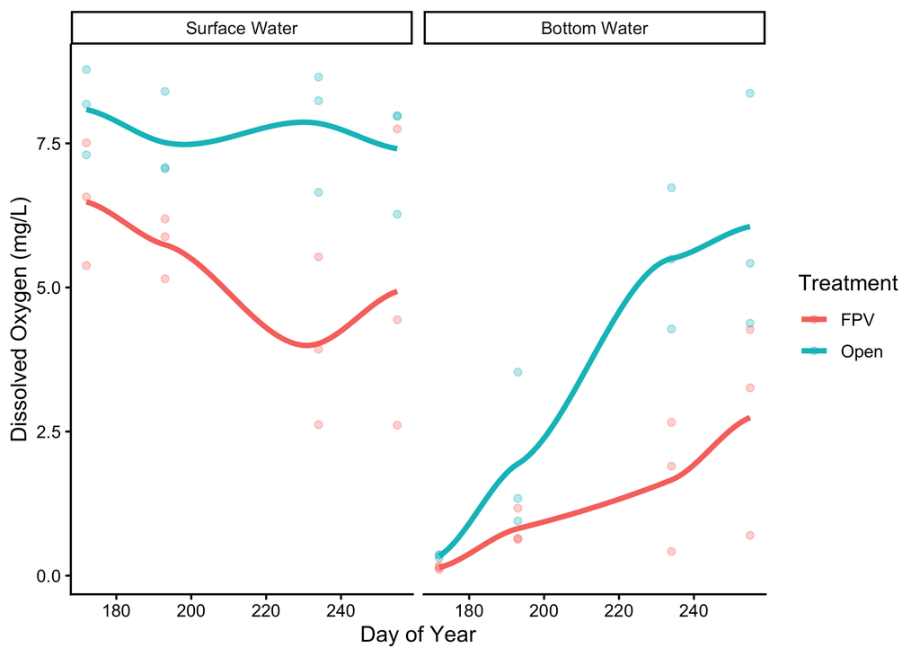

```r
do_mgl_simple <- do_abundance %>%
  group_by(JDate.x, Pond.x, solar_progress.x, Depth_Class.x) %>%
  summarise(avg_do = mean(HDO_mg.l, na.rm = TRUE), .groups = "drop") %>%
  ggplot(aes(x = JDate.x,
             y = avg_do,
             color = solar_progress.x,
             fill = solar_progress.x,
             group = Pond.x)) +
 # geom_line(alpha = 0.1) +
  geom_smooth(aes(group = solar_progress.x), se = FALSE, linewidth = 1.4) +
  geom_point(alpha = 0.3) +
  #scale_shape_manual(values = pond_shapes)+
  ggh4x::facet_wrap2(~Depth_Class.x) +
  labs(
    y = "Dissolved Oxygen (mg/L)",
    x = "Day of Year") +
  guides(
    color = guide_legend(title = "Treatment"),
    fill = "none") +
  theme_classic2()
do_mgl_simple
```

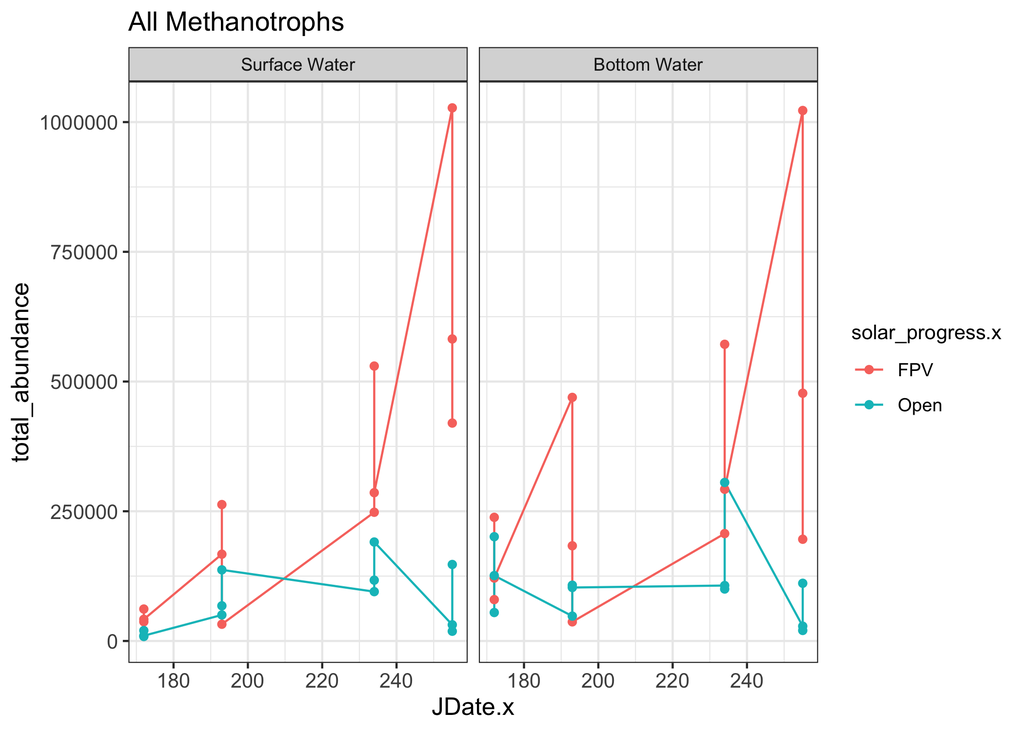

```r
# 2. plot all methanotroph abundances overtime
methanotroph_abundance <- do_abundance %>%
  dplyr::filter(CH4_Cycler == "Methanotroph") %>%
  group_by(JDate.x, Pond.x, solar_progress.x, Depth_Class.x, HDO_mg.l) %>%
  summarise(
    total_abundance = sum(Abundance, na.rm = TRUE), # total across all samples
    .groups = "drop") %>%
 # summarise(avg_do = mean(HDO_mg.l, na.rm = TRUE), .groups = "drop") %>%
  ggplot(aes(x = JDate.x,
             y = total_abundance,
             color = solar_progress.x,
             fill = solar_progress.x)) +
  geom_line() +
  geom_point() +
  labs(title = "All Methanotrophs") +
  #geom_smooth(aes(group = solar_progress.x), se = FALSE, linewidth = 1.4) +
  ggh4x::facet_wrap2(~Depth_Class.x)
methanotroph_abundance
```

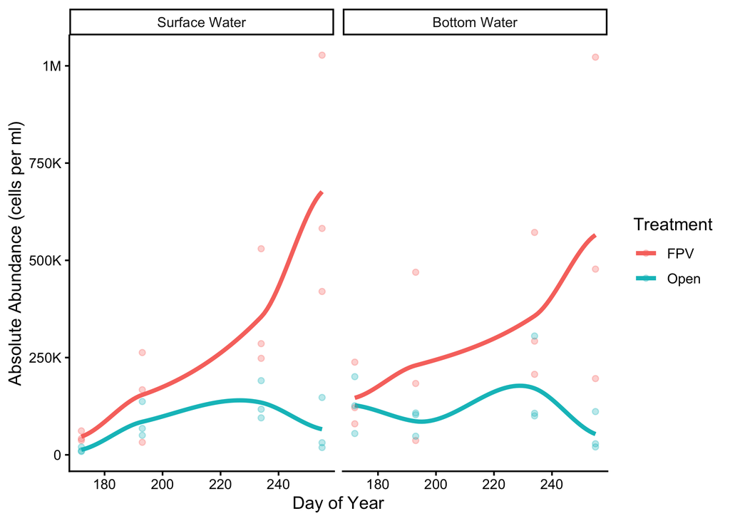

```r
# 2 simple; still plot all methanotrophs, just make it simpler and not shape by pond
methanotroph_all_abund_simple <- do_abundance %>%
  dplyr::filter(CH4_Cycler == "Methanotroph") %>%
  group_by(JDate.x, Pond.x, solar_progress.x, Depth_Class.x) %>%
  summarise(
    total_abundance = sum(Abundance, na.rm = TRUE), # total across all samples
    .groups = "drop") %>%
 # summarise(avg_do = mean(HDO_mg.l, na.rm = TRUE), .groups = "drop") %>%
  ggplot(aes(x = JDate.x,
             y = total_abundance,
             color = solar_progress.x,
             fill = solar_progress.x,
             group = Pond.x)) +
  #geom_line() +
  geom_smooth(aes(group = solar_progress.x), se = FALSE, linewidth = 1.4) +
  geom_point(alpha = 0.3) +
  labs(#title = "All Methanotroph Abundances",
       y = "Absolute Abundance (cells per ml)",
       x = "Day of Year") +
  guides(
    color = guide_legend(title = "Treatment"),
    fill = "none") +
  scale_y_continuous(labels = label_number(scale_cut = cut_short_scale(), accuracy = 1)) +
  ggh4x::facet_wrap2(~Depth_Class.x) +
  theme_classic2()
methanotroph_all_abund_simple
```

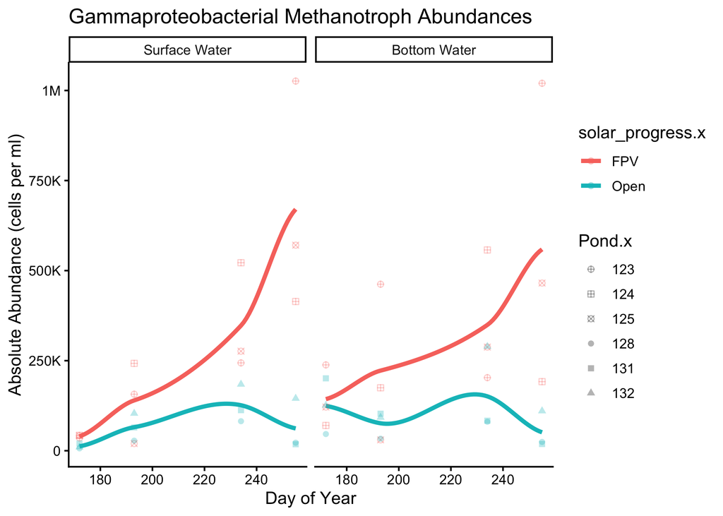

```r
# 2a. plot only gammaproteobacterial methanotroph abundances overtime
gamma_mob_abundance <- do_abundance %>%
  dplyr::filter(CH4_Cycler == "Methanotroph" & Class == "Gammaproteobacteria") %>%
  group_by(JDate.x, Pond.x, solar_progress.x, Depth_Class.x) %>%
  summarise(
    total_abundance = sum(Abundance, na.rm = TRUE), # total across all samples
    .groups = "drop") %>%
  ggplot(aes(x = JDate.x,
             y = total_abundance,
             color = solar_progress.x,
             fill = solar_progress.x,
             group = Pond.x,
             shape = Pond.x)) +
  geom_smooth(aes(group = solar_progress.x), se = FALSE, linewidth = 1.4) +
  geom_point(alpha = 0.3) +
  labs(title = "Gammaproteobacterial Methanotroph Abundances",
       y = "Absolute Abundance (cells per ml)",
       x = "Day of Year") +
  scale_y_continuous(labels = label_number(scale_cut = cut_short_scale(), accuracy = 1)) +
  ggh4x::facet_wrap2(~Depth_Class.x) +
  scale_shape_manual(values = pond_shapes) +
  theme_classic2()
gamma_mob_abundance
```

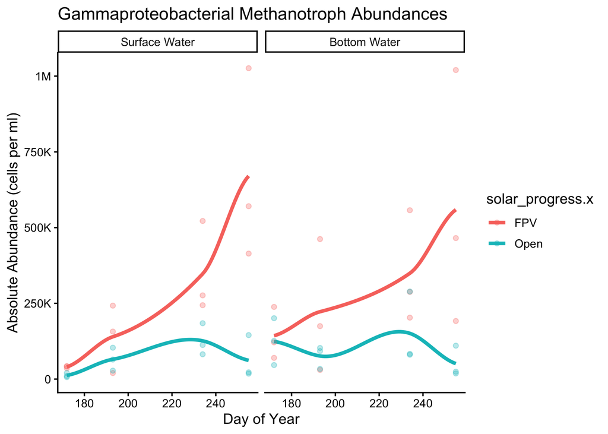

```r
# 2a simple. plot only gammaproteobacterial methanotroph abundances overtime
gamma_mob_abundance_simple <- do_abundance %>%
  dplyr::filter(CH4_Cycler == "Methanotroph" & Class == "Gammaproteobacteria") %>%
  group_by(JDate.x, Pond.x, solar_progress.x, Depth_Class.x) %>%
  summarise(
    total_abundance = sum(Abundance, na.rm = TRUE), # total across all samples
    .groups = "drop") %>%
  ggplot(aes(x = JDate.x,
             y = total_abundance,
             color = solar_progress.x,
             fill = solar_progress.x,
             group = Pond.x)) +
  geom_smooth(aes(group = solar_progress.x), se = FALSE, linewidth = 1.4) +
  geom_point(alpha = 0.3) +
  labs(title = "Gammaproteobacterial Methanotroph Abundances",
       y = "Absolute Abundance (cells per ml)",
       x = "Day of Year") +
  scale_y_continuous(labels = label_number(scale_cut = cut_short_scale(), accuracy = 1)) +
  ggh4x::facet_wrap2(~Depth_Class.x) +
  #scale_shape_manual(values = pond_shapes) +
  theme_classic2()
gamma_mob_abundance_simple
```

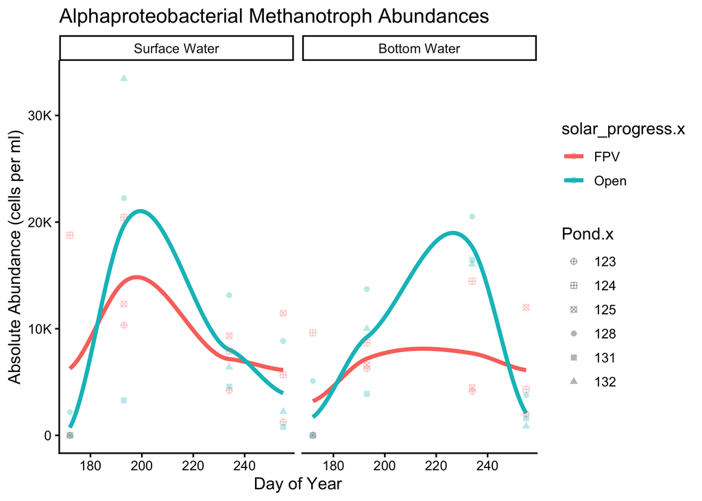

```r
# 2b. plot only alphaproteobacterial methanotroph abundances overtime
alpha_mob_abundance <- do_abundance %>%
  dplyr::filter(CH4_Cycler == "Methanotroph" & Class == "Alphaproteobacteria") %>%
  group_by(JDate.x, Pond.x, solar_progress.x, Depth_Class.x) %>%
  summarise(
    total_abundance = sum(Abundance, na.rm = TRUE), # total across all samples
    .groups = "drop") %>%
  ggplot(aes(x = JDate.x,
             y = total_abundance,
             color = solar_progress.x,
             fill = solar_progress.x,
             shape = Pond.x,
             group = Pond.x)) +
  geom_smooth(aes(group = solar_progress.x), se = FALSE, linewidth = 1.4) +
  geom_point(alpha = 0.3) +
  labs(title = "Alphaproteobacterial Methanotroph Abundances",
       y = "Absolute Abundance (cells per ml)",
       x = "Day of Year") +
  scale_y_continuous(labels = label_number(scale_cut = cut_short_scale(), accuracy = 1)) +
  scale_shape_manual(values = pond_shapes) +
  ggh4x::facet_wrap2(~Depth_Class.x) +
  theme_classic2()
alpha_mob_abundance #interesting that Open ponds have higher alphaproteobacterial methanotrophs; very little in FPV ponds; abundances are less than 80k for alphaproteo methanotrophs in Open ponds though but compared to FPV which have ~20k
```

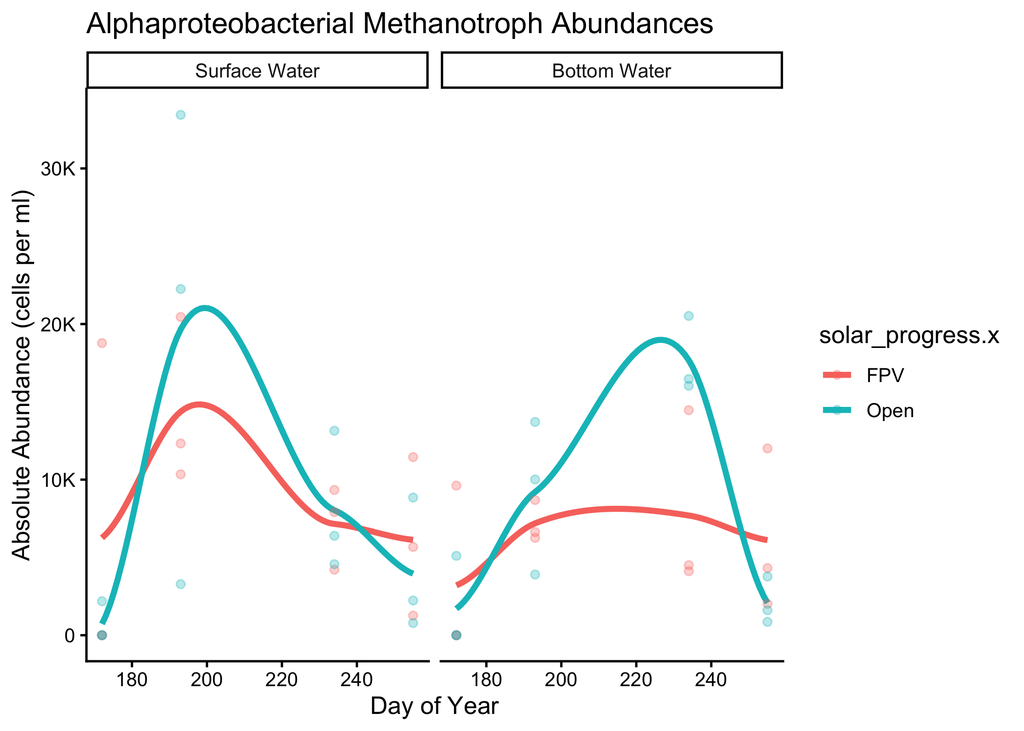

```r
# 2b simple. plot only alphaproteobacterial methanotroph abundances overtime; simply and not shaped by pond
alpha_mob_abundance_simple <- do_abundance %>%
  dplyr::filter(CH4_Cycler == "Methanotroph" & Class == "Alphaproteobacteria") %>%
  group_by(JDate.x, Pond.x, solar_progress.x, Depth_Class.x) %>%
  summarise(
    total_abundance = sum(Abundance, na.rm = TRUE), # total across all samples
    .groups = "drop") %>%
  ggplot(aes(x = JDate.x,
             y = total_abundance,
             color = solar_progress.x,
             fill = solar_progress.x,
             group = Pond.x)) +
  geom_smooth(aes(group = solar_progress.x), se = FALSE, linewidth = 1.4) +
  geom_point(alpha = 0.3) +
  labs(title = "Alphaproteobacterial Methanotroph Abundances",
       y = "Absolute Abundance (cells per ml)",
       x = "Day of Year") +
  scale_y_continuous(labels = label_number(scale_cut = cut_short_scale(), accuracy = 1)) +
  ggh4x::facet_wrap2(~Depth_Class.x) +
  theme_classic2()
alpha_mob_abundance_simple
```

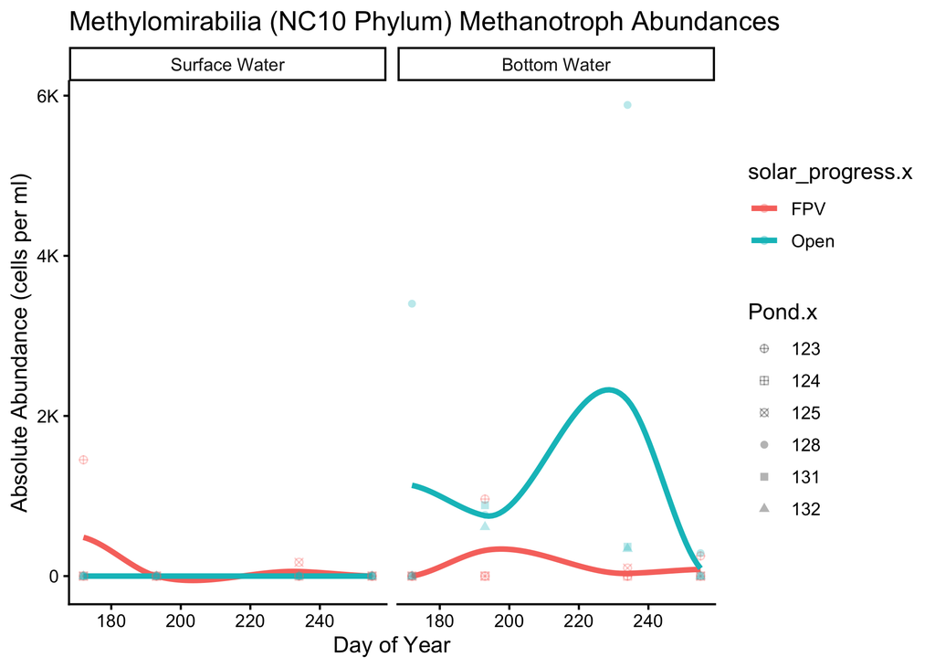

```r
# 2c. plot only Methylomirabilia methanotroph abundances overtime (NC10 phylum); these are anaerobic bacterial methanotrophs that couples denitrification to methane oxidation! (AOM = anaerobic oxidation of methane)
methylomirabilia_aom_abundance <- do_abundance %>%
  dplyr::filter(CH4_Cycler == "Methanotroph" & Class == "Methylomirabilia") %>%
  group_by(JDate.x, Pond.x, solar_progress.x, Depth_Class.x) %>%
  summarise(
    total_abundance = sum(Abundance, na.rm = TRUE), # total across all samples
    .groups = "drop") %>%
  ggplot(aes(x = JDate.x,
             y = total_abundance,
             color = solar_progress.x,
             fill = solar_progress.x,
             shape = Pond.x,
             group = Pond.x)) +
  geom_smooth(aes(group = solar_progress.x), se = FALSE, linewidth = 1.4) +
  geom_point(alpha = 0.3) +
  labs(title = "Methylomirabilia (NC10 Phylum) Methanotroph Abundances",
       y = "Absolute Abundance (cells per ml)",
       x = "Day of Year") +
  scale_y_continuous(labels = label_number(scale_cut = cut_short_scale(), accuracy = 1)) +
  scale_shape_manual(values = pond_shapes) +
  ggh4x::facet_wrap2(~Depth_Class.x) +
  theme_classic2()
methylomirabilia_aom_abundance #super lowly abundant in both FPV and Open ponds. virtually nonexistent in FPV ponds at both depths. virtually nonexistent in surface for Open ponds too; lowly abundant in Open bottom waters ~2k but completely crashes by last time point
```

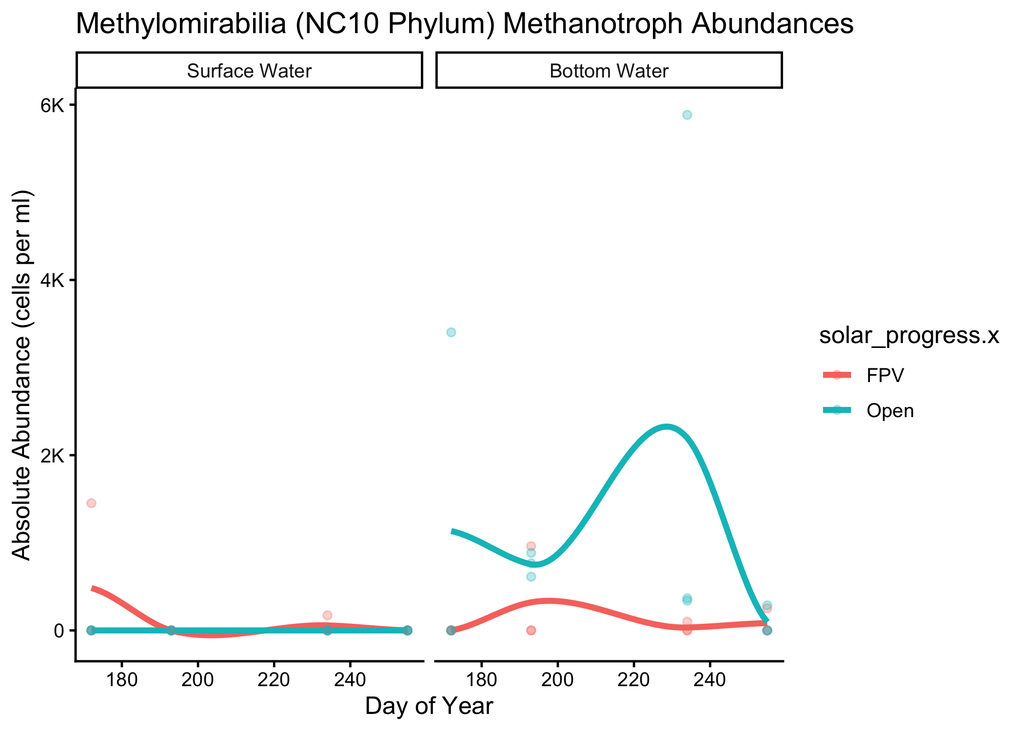

```r
# 2c simple. plot only NC10 phylum (Methylomirabilia class) methanotroph abundances overtime; simply and not shaped by pond
methylomirabilia_aom_abundance_simple <- do_abundance %>%
  dplyr::filter(CH4_Cycler == "Methanotroph" & Class == "Methylomirabilia") %>%
  group_by(JDate.x, Pond.x, solar_progress.x, Depth_Class.x) %>%
  summarise(
    total_abundance = sum(Abundance, na.rm = TRUE), # total across all samples
    .groups = "drop") %>%
  ggplot(aes(x = JDate.x,
             y = total_abundance,
             color = solar_progress.x,
             fill = solar_progress.x,
             group = Pond.x)) +
  geom_smooth(aes(group = solar_progress.x), se = FALSE, linewidth = 1.4) +
  geom_point(alpha = 0.3) +
  labs(title = "Methylomirabilia (NC10 Phylum) Methanotroph Abundances",
       y = "Absolute Abundance (cells per ml)",
       x = "Day of Year") +
  scale_y_continuous(labels = label_number(scale_cut = cut_short_scale(), accuracy = 1)) +
  ggh4x::facet_wrap2(~Depth_Class.x) +
  theme_classic2()
methylomirabilia_aom_abundance_simple
```

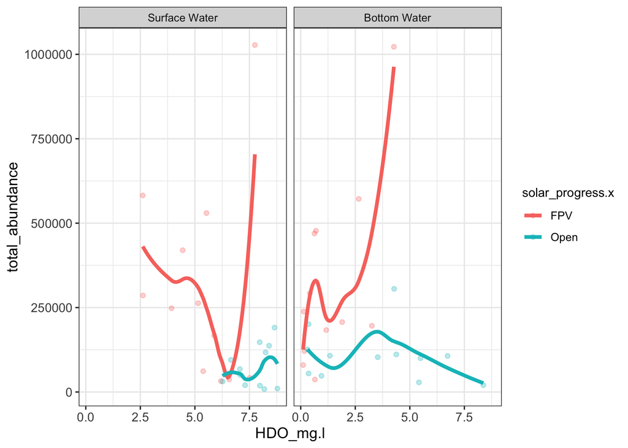

```r
# plot DO vs methanotroph abundance
## note: we are plotting all methanotrophs (gammaproteobacterial and alphaproteobacterial); should the specific gammmaproteobacterial methanotrophs become an interest then we must reprocess the dataframe to filter specifically for gammaproteos/ type I methanotrophs

abundvs_do_mgl <- do_abundance %>%
  dplyr::filter(CH4_Cycler == "Methanotroph") %>%
  group_by(JDate.x, Pond.x, solar_progress.x, Depth_Class.x, HDO_mg.l) %>%
  summarise(
    total_abundance = sum(Abundance, na.rm = TRUE), # total across all samples
    .groups = "drop") %>%
 # summarise(avg_do = mean(HDO_mg.l, na.rm = TRUE), .groups = "drop") %>%
  ggplot(aes(x = HDO_mg.l,
             y = total_abundance,
             color = solar_progress.x,
             fill = solar_progress.x,
             group = Pond.x)) +
 # geom_line() +
  geom_point(alpha = 0.3) +
  geom_smooth(aes(group = solar_progress.x), se = FALSE, linewidth = 1.4) +
  ggh4x::facet_wrap2(~Depth_Class.x)
abundvs_do_mgl
```